# N5 Prelim Revision Booklet - Web Version

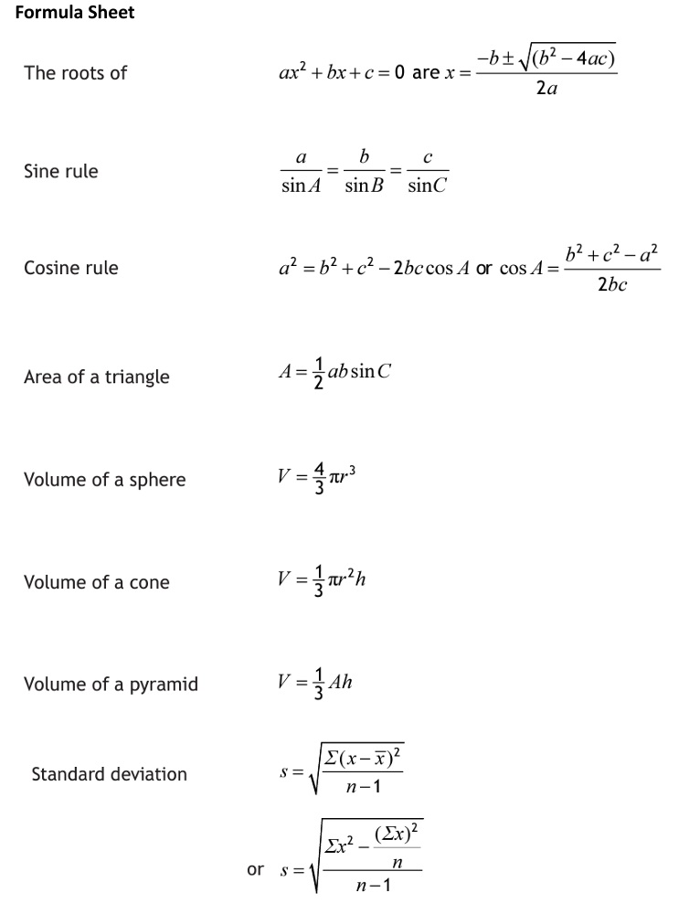

## Volume

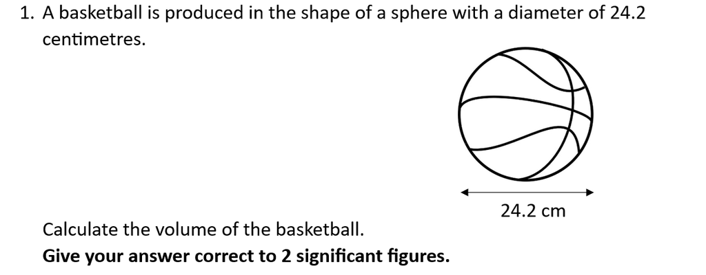

The formula sheet shows how to calculate the volume of a sphere.

$7400\text{ cm}^3$

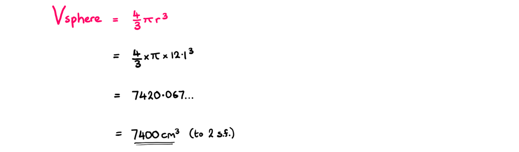

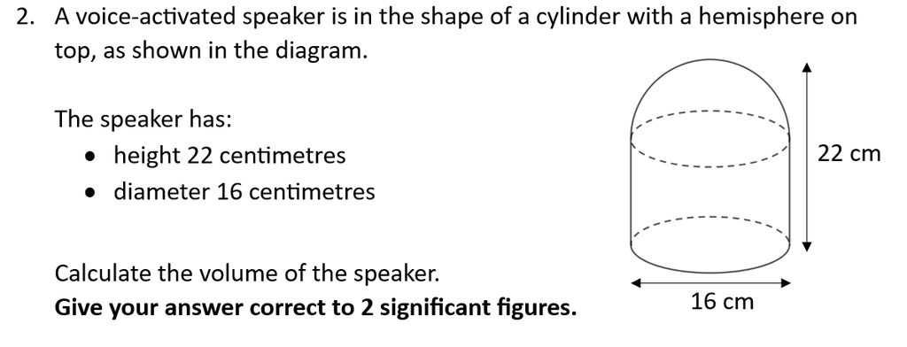

What is the height of the cylinder itself, without the hemisphere on top?

$3900\text{ cm}^3$

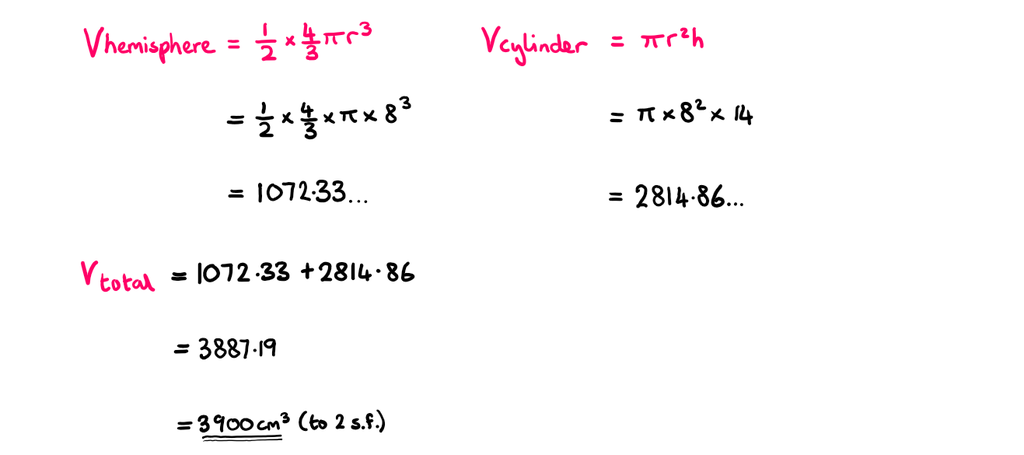

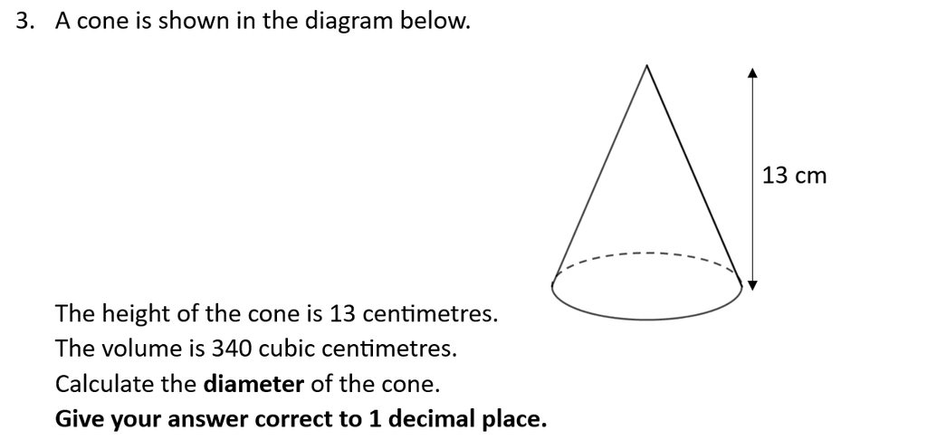

Substitute the values you know into the formula provided on the formula sheet.

$10.0\text{ cm}$

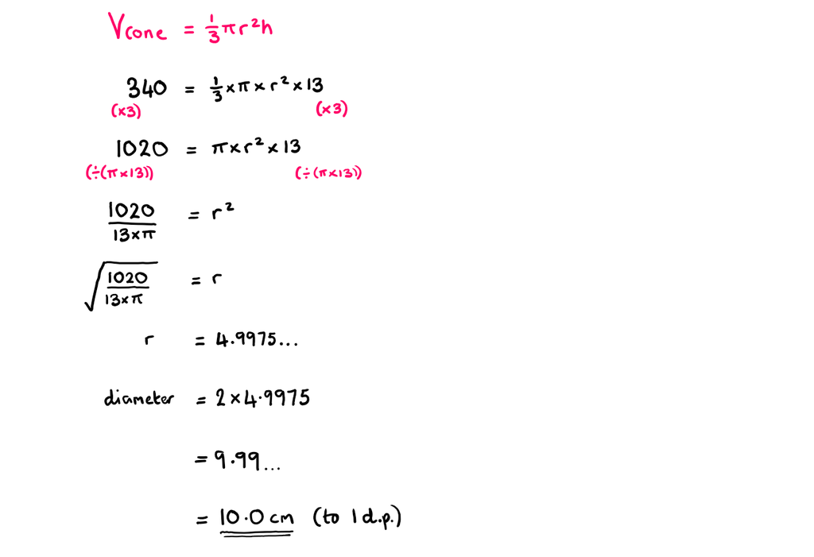

## Equations and Inequations

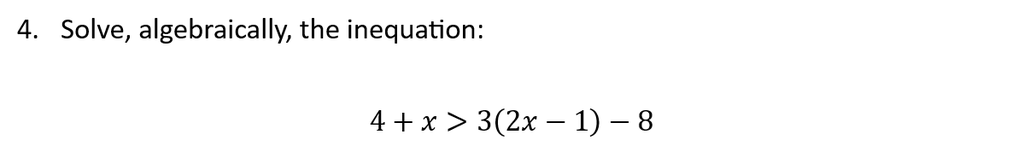

Be very careful if you find yourself dividing *by a negative number*. It is usually best to avoid it.

$3>x$ or $x<3$

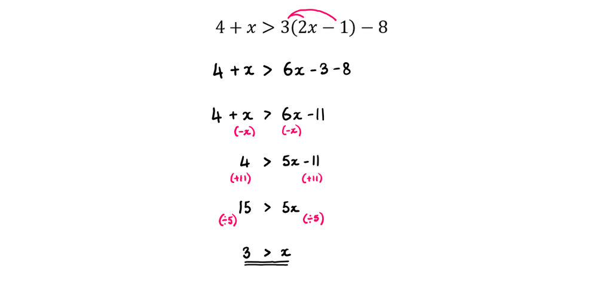

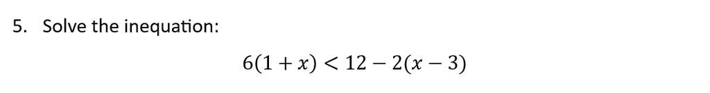

The bracket in the first line is being multiplied by *negative* 2.

$x<\frac{3}{2}$ or $\frac{3}{2}>x$

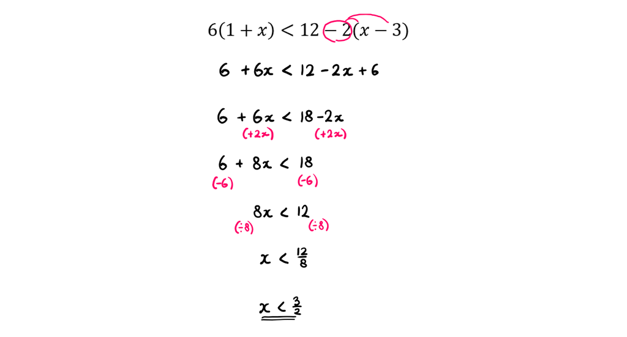

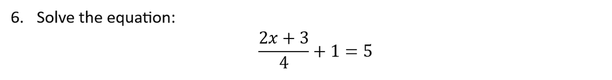

*Multiplying* through carefully by the *denominator* will deal with the fraction.

$x=\frac{13}{2}$

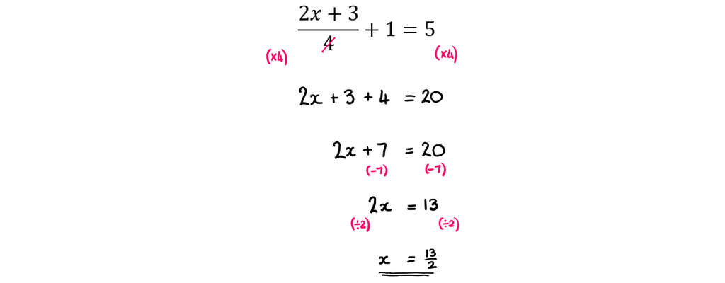

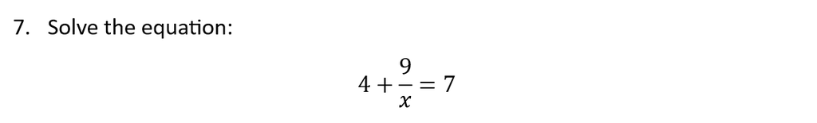

Multiplying by the denominator is a good strategy even when the denominator contains a letter.

$x=3$

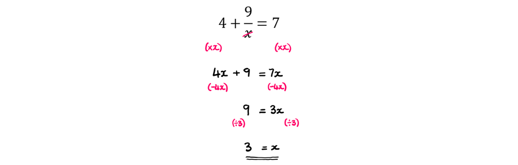

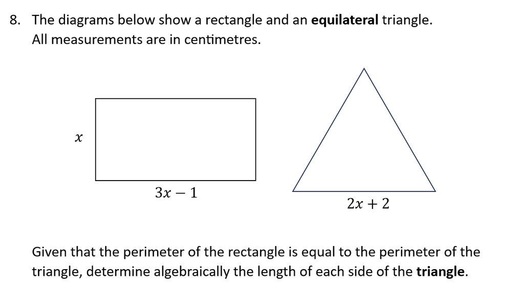

Find an expression for the *perimeter* of each shape first. You are told they have *equal* perimeter...

$10\text{ cm}$

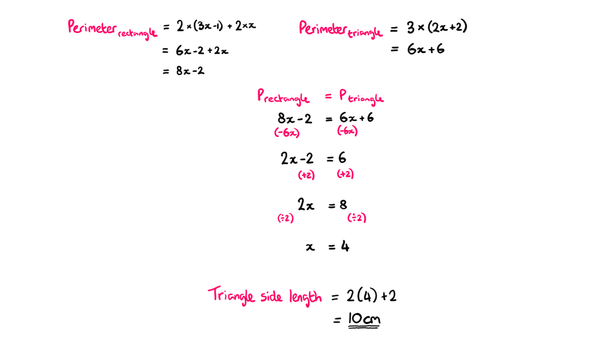

## Circle Geometry

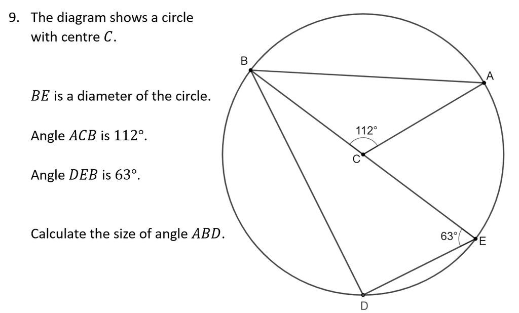

Look for right-angles, and isosceles triangles.

$\angle ABD=61^{\circ}$

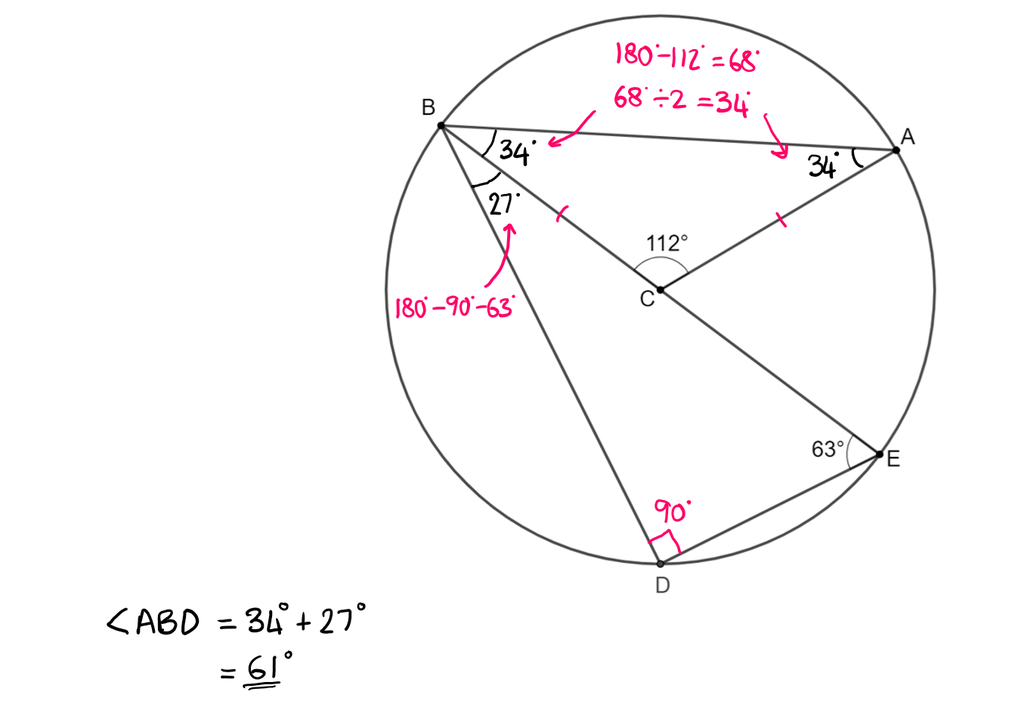

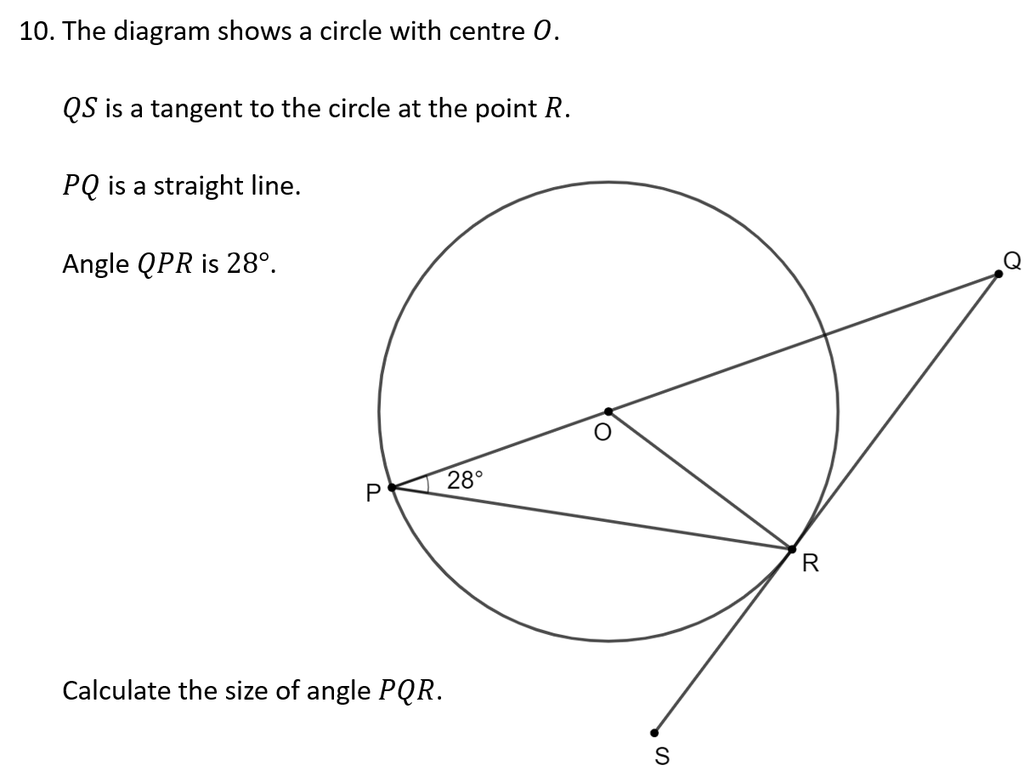

Look for right-angles, and isosceles triangles.

$\angle PQR = 34^{\circ}$

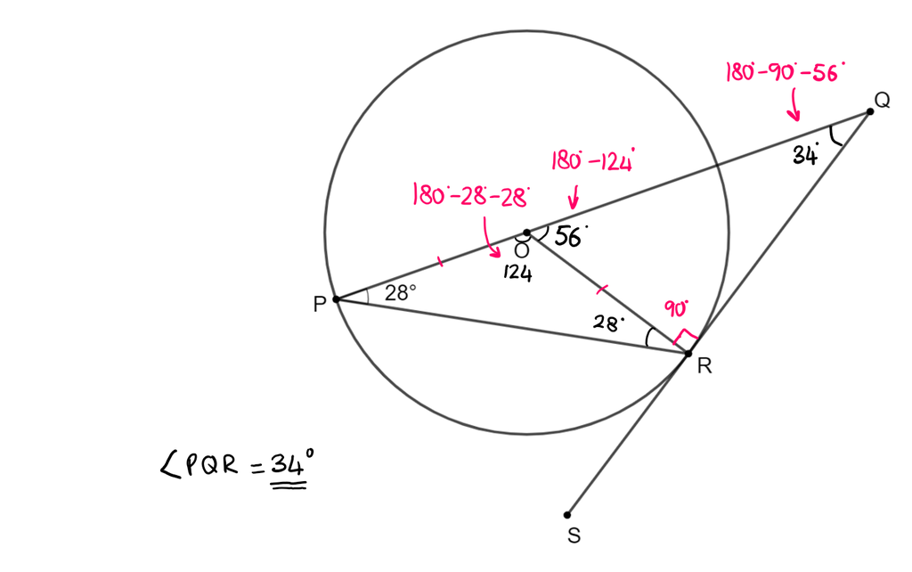

## Scientific Notation

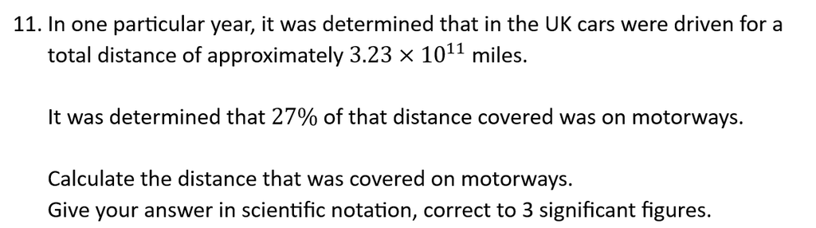

Make sure you can enter numbers in scientific notation *into your calculator* to perform calculations.

$8.72\times10^{10}\text{ miles}$

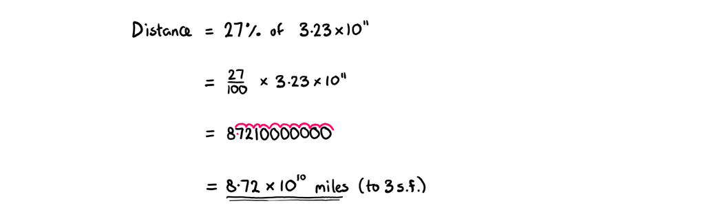

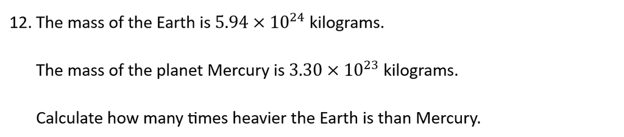

Make sure you can enter numbers in scientific notation into your calculator, and consider whether they should be put them in *brackets* when performing calculators.

$18$

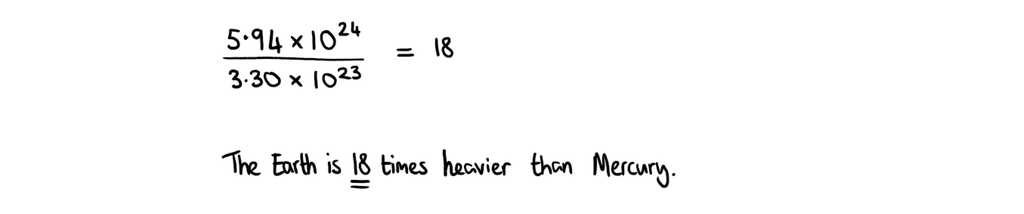